# Discussion Section Worksheet #9

Anupama Bhatta

December 4, 2023

# Learning objectives

- Interpret a regression model for statistical significance
- Test if conditions are met for inference

In class, we used the `evals` dataset of teacher evaluations to explore regression. In Chapter 10 of Modern Dive, we also used this dataset to work through an example of doing statistical inference with regression. We'll build on that example here.

## Make a regression model

Does teacher *age* relate to their teaching evaluation score? Fit a regression model to see the relationship.

```r
library(moderndive)
library(dplyr)
```

```r
library(ggplot2)

score_model <- lm(score ~ age, data = evals)
get_regression_table(score_model)
```

```
## # A tibble: 2 × 7
##   term      estimate std_error statistic p_value lower_ci upper_ci
##   <chr>        <dbl>     <dbl>     <dbl>   <dbl>    <dbl>    <dbl>
## 1 intercept    4.46      0.127     35.2    0        4.21     4.71
## 2 age         -0.006     0.003     -2.31   0.021   -0.011   -0.001
```

## Interpret the regression table

What would the equation for the line be relating age to teaching evaluation score? **score = β0 + β1 × Age + error**

In plain language, and with reference to the data and variables we're modeling, explain what the following elements of the table mean:

1. Standard error (`std_error`): **The standard error is a measure of the variability or uncertainty associated with the estimated coefficient. It tells us how much we might expect the estimated coefficient to vary if we were to take multiple samples. Smaller standard errors indicate more precise estimates.**
2. p-value (`p_value`): **The p-value assesses the evidence against a null hypothesis. In the context of a regression coefficient, a low p-value (typically less than 0.05) suggests that there is evidence to reject the null hypothesis, indicating that the predictor variable (e.g., age) is likely associated with the response variable (e.g., teaching evaluation score).**
3. lower CI (`lower_ci`): **The lower confidence interval provides a range of values within which we can be reasonably confident that the true population parameter (e.g., the true slope or coefficient) lies. It gives a lower bound for the estimate.**
4. upper CI (`upper_ci`): **The upper confidence interval is similar to the lower one but provides an upper bound for the estimate. Together with the lower interval, it gives us a range of values within which we can be reasonably confident the true parameter is likely to fall**

In this table, there is a hypothesis test built in. For that hypothesis test:

1. What is the null hypothesis? **There is no significant relationship between teacher age and teaching evaluation score.**
2. What is the alternative hypothesis? **There is a significant relationship between teacher age and teaching evaluation score.**

Based on the values of the regression table, would you rule out the null hypothesis? Why?  
**Based on the values of the regression table, I would definitely rule out the null hypothesis because the p-value associated with the "age" variable is less than 0.05, which suggests that there is evidence to support the existence of a significant relationship between teacher age and teaching evaluation score.**

## Check the conditions for inference

Ideally, four conditions will be met about your data so that we can be confident making inferences based on the regression model we just fit. For each of those conditions, decide if you think it has been met. You may use graphs or calculations to support your argument.

### Linearity

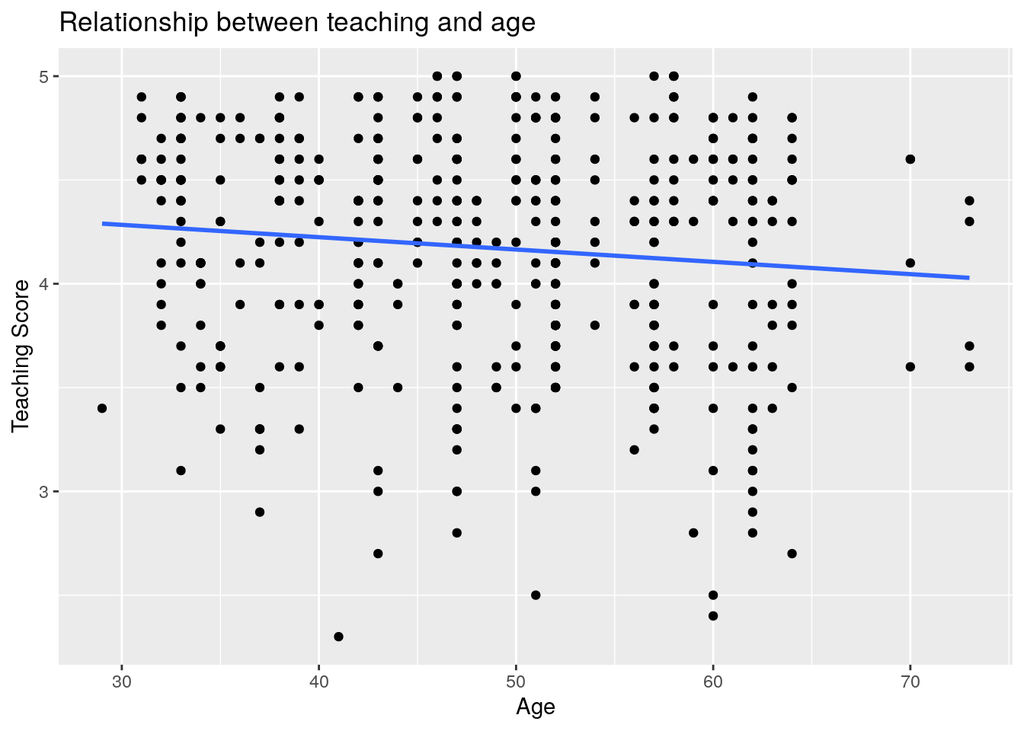

```r
ggplot(evals, aes(x = age, y = score)) +
  geom_point() +
  labs(x = "Age",
       y = "Teaching Score",
       title = "Relationship between teaching and age") +
  geom_smooth(method = "lm", se = FALSE)
```

** Since the points are evenly distributed with no clear pattern, the linearity condition is likely to be met.**

### Independence of residuals

```r
evals %>%
  dplyr::select(ID, prof_ID, score, age)
```

```
## # A tibble: 463 × 4
##       ID prof_ID score   age
##    <int>   <int> <dbl> <int>
##  1     1       1   4.7    36
##  2     2       1   4.1    36
##  3     3       1   3.9    36
##  4     4       1   4.8    36
##  5     5       2   4.6    59
##  6     6       2   4.3    59
##  7     7       2   2.8    59
##  8     8       3   4.1    51
##  9     9       3   3.4    51
## 10    10       4   4.5    40
## # … with 453 more rows
## # ℹ Use `print(n = ...)` to see more rows
```

**As there is dependence among observations, it is likely that the independence condition is not met.**

### Normality of residuals

```r
regression_points <- get_regression_points(score_model)
regression_points
```

```
## # A tibble: 463 × 5
##       ID score   age score_hat residual
##    <int> <dbl> <int>     <dbl>    <dbl>
##  1     1   4.7    36      4.25    0.452
##  2     2   4.1    36      4.25   -0.148
##  3     3   3.9    36      4.25   -0.348
##  4     4   4.8    36      4.25    0.552
##  5     5   4.6    59      4.11    0.488
##  6     6   4.3    59      4.11    0.188
##  7     7   2.8    59      4.11   -1.31
##  8     8   4.1    51      4.16   -0.059
##  9     9   3.4    51      4.16   -0.759
## 10    10   4.5    40      4.22    0.276
## # … with 453 more rows
## # ℹ Use `print(n = ...)` to see more rows
```

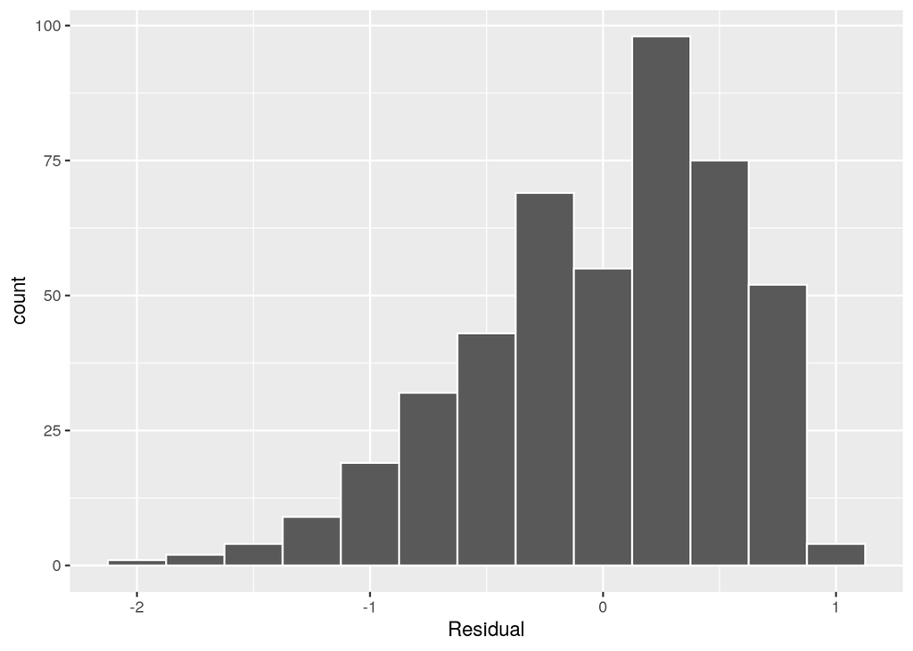

```r
ggplot(regression_points, aes(x = residual)) +
  geom_histogram(binwidth = 0.25, color = "white") +
  labs(x = "Residual")
```

### Equality of variance

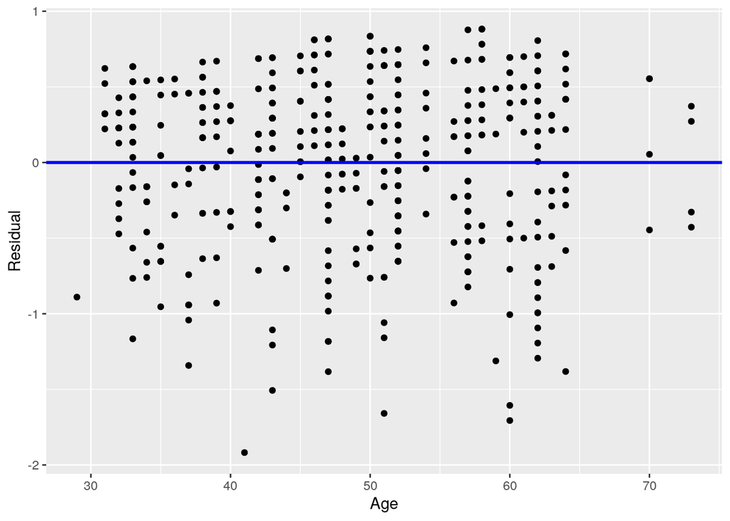

```r
ggplot(regression_points, aes(x = age, y = residual)) +
  geom_point() +
  labs(x = "Age", y = "Residual") +
  geom_hline(yintercept = 0, col = "blue", size = 1)
```

**Since the spread of residuals is roughly constant across all levels of the predictor variable, the equality assumption is most likely met.**

## Conclusion

Based on the conditions you just reviewed, would you feel confident in the results of the hypothesis test? Why or why not? *Note: this can be somewhat subjective!* **Based on the conditions I just reviewed, I feel pretty confident in ruling out the null hypothesis because three out of four conditions were met and the respective validity tests seem to support my inferences.**